# Lecture 6 Neural Networks

# Creating and Comparing Algorithms

```r
library(ISLR)
library(caret)
library(readxl)
library(pROC)
library(lattice)
library(ggplot2)
library(dplyr)
library(e1071)
library(corrplot)
library(kknn)
library(ggplot2)
library(multiROC)
library(MLeval)
library(AppliedPredictiveModeling)
library(corrplot)
library(Hmisc)
library(dplyr)
library(quantmod)

library(nnet)
library(caret)
library(NeuralNetTools)

setwd('C:\\projects\\MachineLearning')

heartdata<-read_excel("heart.xlsx")


heartdata$Sex<-as.character(heartdata$Sex)
heartdata$ChestPainType<-as.character(heartdata$ChestPainType)
heartdata$FastingBPmorethan120<-as.character(heartdata$FastingBPmorethan120)
heartdata$ExerciseInducedAngina<-as.character(heartdata$ExerciseInducedAngina)
heartdata$Thal<-as.character(heartdata$Thal)
heartdata$ColoredVessels<-as.character(heartdata$ColoredVessels)
heartdata$HeartAttackRisk<-as.character(heartdata$HeartAttackRisk)
heartdata$RestingElectrographicResults<-as.character(heartdata$RestingElectrographicResults)


str(heartdata)
```

```
## Classes 'tbl_df', 'tbl' and 'data.frame':    303 obs. of  14 variables:
##  $ Age                         : num  63 37 41 56 57 57 56 44 52 57 ...
##  $ Sex                         : chr  "1" "1" "0" "1" ...
##  $ ChestPainType               : chr  "3" "2" "1" "1" ...
##  $ RestingBloodPressure        : num  145 130 130 120 120 140 140 120 172 150 ...
##  $ Cholesterol                 : num  233 250 204 236 354 192 294 263 199 168 ...
##  $ FastingBPmorethan120        : chr  "1" "0" "0" "0" ...
##  $ RestingElectrographicResults: chr  "0" "1" "0" "1" ...
##  $ MaximumHeartRate            : num  150 187 172 178 163 148 153 173 162 174 ...
##  $ ExerciseInducedAngina       : chr  "0" "0" "0" "0" ...
##  $ Oldpeak                     : num  2.3 3.5 1.4 0.8 0.6 0.4 1.3 0 0.5 1.6 ...
##  $ Slope                       : num  0 0 2 2 2 1 1 2 2 2 ...
##  $ ColoredVessels              : chr  "0" "0" "0" "0" ...
##  $ Thal                        : chr  "1" "2" "2" "2" ...
##  $ HeartAttackRisk             : chr  "1" "1" "1" "1" ...
```

```r
control <- trainControl(method="repeatedcv", number=10, repeats=3)
# NNET
set.seed(100)
fit.nnet <- train(HeartAttackRisk~., data=heartdata, method="nnet", trControl=control,trace=FALSE)
# LDA
set.seed(100)
fit.lda <- train(HeartAttackRisk~., data=heartdata, method="lda", trControl=control)
# SVM
set.seed(100)
fit.svm <- train(HeartAttackRisk~., data=heartdata, method="svmRadial", trControl=control)
# kNN
set.seed(100)
fit.knn <- train(HeartAttackRisk~., data=heartdata, method="knn", trControl=control)
# Random Forest
set.seed(100)
fit.rf <- train(HeartAttackRisk~., data=heartdata, method="rf", trControl=control)

algo_results <- resamples(list(NNET=fit.nnet, LDA=fit.lda, SVM=fit.svm, KNN=fit.knn, RF=fit.rf))

summary(algo_results)
```

```
##
## Call:
## summary.resamples(object = algo_results)
##
## Models: NNET, LDA, SVM, KNN, RF
## Number of resamples: 30
##
## Accuracy
##           Min.   1st Qu.    Median      Mean   3rd Qu.      Max. NA's
## NNET 0.5806452 0.7789210 0.8198925 0.8240180 0.9000000 0.9677419    0
## LDA  0.6666667 0.8064516 0.8643678 0.8483624 0.9000000 1.0000000    0
## SVM  0.6333333 0.7741935 0.8387097 0.8241973 0.8666667 0.9666667    0
## KNN  0.5161290 0.5896552 0.6559140 0.6527438 0.7250000 0.8000000    0
## RF   0.6451613 0.7481183 0.7836485 0.7967730 0.8596774 0.9333333    0
##
## Kappa
##             Min.   1st Qu.    Median      Mean   3rd Qu.      Max. NA's
## NNET  0.15094340 0.5469316 0.6358211 0.6429990 0.8000000 0.9344609    0
## LDA   0.32432432 0.6055024 0.7242133 0.6912806 0.7972848 1.0000000    0
## SVM   0.25339367 0.5426629 0.6742533 0.6431479 0.7345133 0.9315068    0
## KNN  -0.00867679 0.1737474 0.2919374 0.2945343 0.4274648 0.5945946    0
## RF    0.27906977 0.4904654 0.5698878 0.5896368 0.7163996 0.8660714    0
```

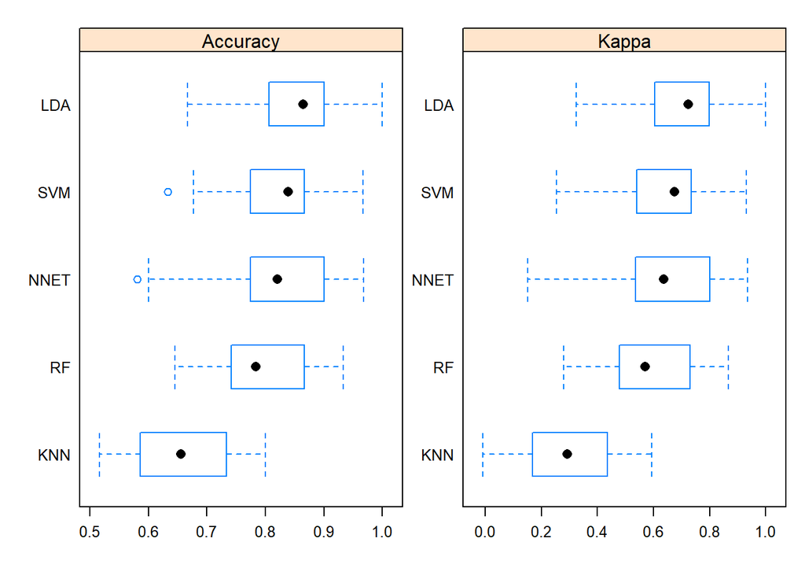

```r
scales <- list(x=list(relation="free"), y=list(relation="free"))
bwplot(algo_results, scales=scales)
```

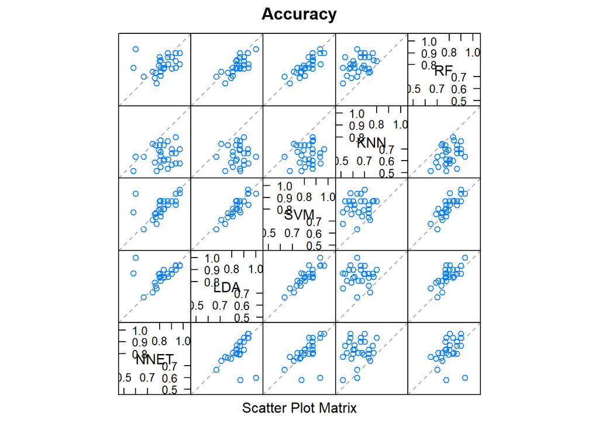

```r
splom(algo_results)
```

```r
diffs <- diff(algo_results)
# summarize p-values for pair-wise comparisons
summary(diffs)
```

```
##
## Call:
## summary.diff.resamples(object = diffs)
##
## p-value adjustment: bonferroni
## Upper diagonal: estimates of the difference
## Lower diagonal: p-value for H0: difference = 0
##
## Accuracy
##      NNET      LDA        SVM        KNN        RF
## NNET           -0.0243443 -0.0001792  0.1712743  0.0272451
## LDA  1.000000              0.0241651  0.1956186  0.0515894
## SVM  1.000000  0.005898               0.1714535  0.0274243
## KNN  4.252e-08 1.470e-09  1.132e-08             -0.1440292
## RF   1.000000  6.431e-05  0.026927   8.561e-09
##
## Kappa
##      NNET      LDA        SVM        KNN        RF
## NNET           -0.0482816 -0.0001489  0.3484646  0.0533622
## LDA  1.00000               0.0481327  0.3967463  0.1016438
## SVM  1.00000   0.00623                0.3486135  0.0535111
## KNN  3.886e-08 1.282e-09  9.522e-09             -0.2951025
## RF   1.00000   8.589e-05  0.03714    5.609e-09
```

# Support Vector Machine

- SVM is a technique of partitioning the multidimensional data using hyperplane referencing the examples and their feature values.
- This mechanism incorporates the instance based learning classification achieved in KNN and numeric prediction achieved Linear Regression.
- SVM can be used for Classification and Numeric Prediction.
- Examples related to SVM applications include identification of cancer by genetic expression patterns, text categorization.
- The hyperplane can partition the examples having the same class values. If the classes are separated perfectly by using the linear hyperplane surface then these classes are called linearly seperable.
- Hyperplane is one dimension less than the dimension used to represent the data. For two dimension the hyperplane is a line versus for a data represented by three dimension the hyperplane is a plane. SVM entails finding the best hyperplane for the division.

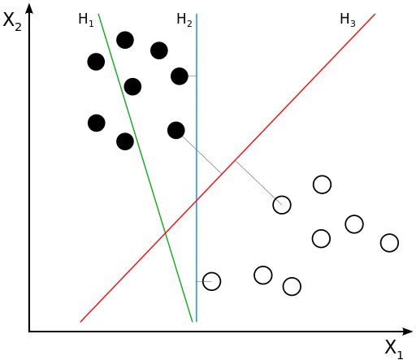

  Support Vector Machine

H1 does not separate the classes. H2 does, but only with a small margin. H3 separates them with the maximal margin.

$$\vec{w}\vec{x}+b=0$$

- Where $\vec{w}$is a set of n vectors representing weights for an n dimensional space. b is the bias. Bias is analogous to the intercept in a slope intercept equation.
- The goal is to find the set of weights that define the hyperplanes as follows:

$$\vec{w}\vec{x}+b\geq1$$
$$\vec{w}\vec{x}+b\le-1$$

The examples if linearly seperable can be separated on either sides of the aforementioned planes. Distance between these two planes by vector geometry is

$$D=\frac{2}{\left|\left|\vec{w}\right|\right|}$$

$$\left|\left|\vec{w}\right|\right|$$
is the Euclidean Norm which is the distance from the origin to vector w https://en.wikipedia.org/wiki/Euclidean_distance To maximises the Distance the Euclidean norm has to be minimized. This can be symbolically represented as follows:

$$min\frac{\mathbf{1}\left|\left|\vec{w}\right|\right|^\mathbf{2}}{\mathbf{2}}$$
such that
$$y_i(\vec{w}{x_i}-b)\geq1$$
for all
$$\vec{x_i}$$

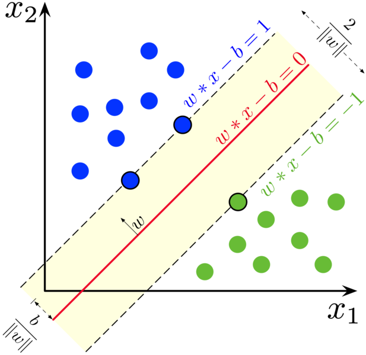

Support Vector Machine

We are minimizing the norm and to make the math easier the we divide by 2 and the second line states that this is subject to the yi point is classified accurately. Y essentially indicated the class and is transformed to 1 or -1. The process is intensive therefore quadratic programming performs the appropriate steps.

# Non Linearly Separable Data:

- If the data are not linearly separable creating soft boundary margin by the use of a slack variable which allows for some misclassification. A cost value is used to penalize the misclassified points and instead of finding the MMH the total cost is minimized.

$${min}\frac{\mathbf{1}\left|\left|\vec{w}\right|\right|^\mathbf{2}}{\mathbf{2}}+{C}\sum_{{i}=\mathbf{1}}^{{n}}{\varepsilon}_{i}$$

such that

$${y}_{i}\left({w}{x}_{i}-b\right)\geq1-\varepsilon_i\forall{x}_{i}\varepsilon_i>=0$$

- The higher the C value the harder the optimization algorithm will work to obtain absolute separation. A lower C value gives priority to get a wider margin. The two paradigm have to balanced and the balance determines the creation of a model that generalizes well for the test data.

#Kernels Non Linear spaces:

- SVM can still be classified by introducing a slack variable and some of the examples will be misclassified
- A technique called Kernel trick if applied transforms the space to a higher dimension. This introduction helps to linearlize the space due the change in perspective.

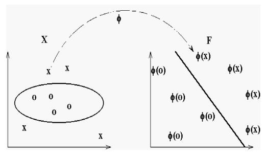

Support Vector Machine

- Illustration of the mapping
  $${\displaystyle \varphi }\varphi$$
  . On the left a set of samples in the input space, on the right the same samples in the feature space where the polynomial kernel
  $${\displaystyle K(x,y)}$$
  (for some values of the parameters
  $${\displaystyle c}$$
  and
  $${\displaystyle d}$$
  is the inner product. The hyperplane learned in feature space by an SVM is an ellipse in the input space. +In machine learning, the polynomial kernel is a kernel function commonly used with support vector machines (SVMs) and other kernelized models, that represents the similarity of vectors (training samples) in a feature space over polynomials of the original variables, allowing learning of non-linear models.
- Intuitively, the polynomial kernel looks not only at the given features of input samples to determine their similarity, but also combinations of these. In the context of regression analysis, such combinations are known as interaction features. The (implicit) feature space of a polynomial kernel is equivalent to that of polynomial regression, but without the combinatorial blowup in the number of parameters to be learned. When the input features are binary-valued (booleans), then the features correspond to logical conjunctions of input features. https://gist.github.com/WittmannF/60680723ed8dd0cb993051a7448f7805
- For degree-d polynomials, the polynomial kernel is defined as[2]

$${\displaystyle K(x,y)=(x^{\mathsf {T}}y+c)^{d}}K(x,y) = (x^\mathsf{T} y + c)^{d}$$
where x and y are vectors in the input space, i.e. vectors of features computed from training or test samples and c ≥ 0 is a free parameter trading off the influence of higher-order versus lower-order terms in the polynomial. When c = 0, the kernel is called homogeneous.[3] (A further generalized polykernel divides xTy by a user-specified scalar parameter a.[4])

- As a kernel, K corresponds to an inner product in a feature space based on some mapping φ:

$${\displaystyle K(x,y)=\langle \varphi (x),\varphi (y)\rangle }K(x,y) = \langle \varphi(x), \varphi(y) \rangle$$

  $$\emptyset$$
  is the mapping that converts the space to a higher dimension. Linear Kernel transformation therefore it can be depicted as the product of the features.
  $$K\left({x}_{i},{x}_{j}\right)=\left({x}_{i}\right)\ast\left({x}_{j}\right)$$
  # Polynomial Kernel

Adds a simple non linear transformation:

$$K\left({x}_{i},{x}_{j}\right)=\left({x}_{i}\ast{x}_{j}+\mathbf{1}\right)^d$$